# Data Analysis

### 9.4.4 Moderation effect

Does subspecialty affect the difference in waiting times between private and Medicaid? The ANOVA table below shows that yes, we have evidence for the interaction.

```r
lmmodel2 <-
  glmer(days ~
          subspecialty * insurance_type +
          age_category+
          District +
          central +
          gender +
          dow +
          ntransf +
          provider + (1|name),
               data = final5,
               family = poisson, #Count data
               nAGQ = 1)

tab_model(lmmodel2)
```

|  | days |  |  |
| --- | --- | --- | --- |
| Predictors | Incidence Rate Ratios | CI | p |
| (Intercept) | 17.06 | 8.26 – 35.22 | **<0.001** |
| subspecialty [Fem PM & RM] | 1.45 | 1.17 – 1.80 | **0.001** |
| subspecialty [Mat-Fet Med] | 1.47 | 1.16 – 1.86 | **0.001** |
| subspecialty [Reprod End & Infert] | 2.37 | 1.75 – 3.22 | **<0.001** |
| insurance type [Medicaid] | 1.44 | 1.27 – 1.64 | **<0.001** |
| age category [40 to 49 years old] | 1.26 | 0.94 – 1.69 | 0.129 |
| age category [50 to 59 years old] | 1.35 | 1.01 – 1.82 | **0.046** |
| age category [60 years old or greater] | 1.36 | 1.00 – 1.87 | 0.054 |
| District [District II] | 0.81 | 0.59 – 1.13 | 0.211 |
| District [District III] | 1.02 | 0.76 – 1.38 | 0.886 |
| District [District IV] | 1.00 | 0.73 – 1.36 | 0.982 |
| District [District IX] | 0.97 | 0.68 – 1.40 | 0.889 |
| District [District V] | 0.92 | 0.67 – 1.28 | 0.637 |
| District [District VI] | 0.80 | 0.59 – 1.09 | 0.162 |
| District [District VII] | 0.85 | 0.59 – 1.22 | 0.381 |
| District [District VIII] | 0.96 | 0.68 – 1.36 | 0.832 |
| District [District XI] | 0.88 | 0.61 – 1.25 | 0.466 |
| District [District XII] | 1.01 | 0.64 – 1.60 | 0.975 |
| District [Missing] | 0.80 | 0.50 – 1.30 | 0.368 |
| central [No] | 1.02 | 0.91 – 1.14 | 0.780 |
| gender [Male] | 0.84 | 0.72 – 0.98 | **0.026** |
| dow [Tuesday] | 1.02 | 0.90 – 1.16 | 0.731 |
| dow [Wednesday] | 0.79 | 0.72 – 0.88 | **<0.001** |
| dow [Thursday] | 0.72 | 0.63 – 0.82 | **<0.001** |
| dow [Friday] | 0.70 | 0.60 – 0.81 | **<0.001** |
| ntransf [No transfers] | 0.81 | 0.61 – 1.06 | 0.125 |
| ntransf [One transfer] | 0.90 | 0.68 – 1.17 | 0.425 |
| ntransf [Two transfers] | 0.93 | 0.69 – 1.24 | 0.616 |
| provider [MD] | 0.64 | 0.37 – 1.11 | 0.110 |
| subspecialty [Fem PM & RM] * insurance type [Medicaid] | 1.17 | 1.00 – 1.36 | 0.053 |
| subspecialty [Mat-Fet Med] * insurance type [Medicaid] | 0.75 | 0.63 – 0.90 | **0.001** |
| subspecialty [Reprod End & Infert] * insurance type [Medicaid] | 0.86 | 0.68 – 1.09 | 0.205 |
| Random Effects |  |  |  |
| σ<sup>2</sup> | 0.07 |  |  |
| τ<sub>00</sub> <sub>name</sub> | 0.43 |  |  |
| ICC | 0.86 |  |  |
| N <sub>name</sub> | 354 |  |  |
| Observations | 532 |  |  |
| Marginal R<sup>2</sup> / Conditional R<sup>2</sup> | 0.180 / 0.883 |  |  |

```r
car::Anova(lmmodel2, type = 3)
```

```
## Analysis of Deviance Table (Type III Wald chisquare tests)
##
## Response: days
##                               Chisq Df Pr(>Chisq)
## (Intercept)                 58.8035  1  1.742e-14 ***
## subspecialty                32.4671  3  4.172e-07 ***
## insurance_type              30.6675  1  3.063e-08 ***
## age_category                 4.5762  3    0.20559
## District                     5.7975 11    0.88653
## central                      0.0779  1    0.78022
## gender                       4.9340  1    0.02633 *
## dow                         34.4234  4  6.101e-07 ***
## ntransf                      5.4681  3    0.14056
## provider                     2.5614  1    0.10950
## subspecialty:insurance_type 48.1458  3  1.983e-10 ***
## ---
## Signif. codes:  0 '***' 0.001 '**' 0.01 '*' 0.05 '.' 0.1 ' ' 1
```

We can graph the interaction to interpret it.

In general waiting time is longer for Medicaid, but mroe so in two subspecialties.

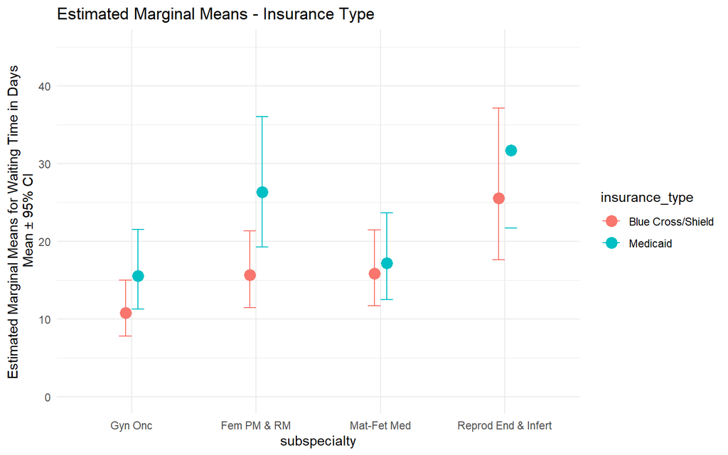

```r
edata <- emmeans(lmmodel2, ~ insurance_type | subspecialty,
                 type = "response",nuisance = c("District","central","gender",
                     "ntransf","provider")) %>%
  as.data.frame()

ggplot(edata, aes(x = subspecialty, y = rate))+
  geom_point(aes(color = insurance_type), size = 2, stroke = 2,
                 position = position_dodge(width=0.2))+
  geom_errorbar(aes(ymin = asymp.LCL, ymax = asymp.UCL,
                    color = insurance_type), width = 0.2,
                position = position_dodge(width=0.2))+
  ylim(0,45)+
  ggtitle("Estimated Marginal Means - Insurance Type")+
  ylab("Estimated Marginal Means for Waiting Time in Days\n Mean ± 95% CI")+
  theme_minimal()
```

Usually the graph above should be good enough, but people always want to conduct statistical tests.

```r
emmeans(lmmodel2, pairwise~ insurance_type | subspecialty,
        nuisance = c("District","central","gender",
                     "ntransf","provider"),
                 type = "response")
```

```
## $emmeans
## subspecialty = Gyn Onc:
##  insurance_type    rate   SE  df asymp.LCL asymp.UCL
##  Blue Cross/Shield 10.8 1.80 Inf      7.76      14.9
##  Medicaid          15.5 2.57 Inf     11.25      21.5
##
## subspecialty = Fem PM & RM:
##  insurance_type    rate   SE  df asymp.LCL asymp.UCL
##  Blue Cross/Shield 15.6 2.48 Inf     11.46      21.3
##  Medicaid          26.3 4.21 Inf     19.23      36.0
##
## subspecialty = Mat-Fet Med:
##  insurance_type    rate   SE  df asymp.LCL asymp.UCL
##  Blue Cross/Shield 15.8 2.45 Inf     11.66      21.4
##  Medicaid          17.2 2.80 Inf     12.47      23.6
##
## subspecialty = Reprod End & Infert:
##  insurance_type    rate   SE  df asymp.LCL asymp.UCL
##  Blue Cross/Shield 25.5 4.87 Inf     17.58      37.1
##  Medicaid          31.7 6.14 Inf     21.65      46.3
##
## Results are averaged over the levels of: 5 nuisance factors, age_category, dow
## Confidence level used: 0.95
## Intervals are back-transformed from the log scale
##
## $contrasts
## subspecialty = Gyn Onc:
##  contrast                       ratio     SE  df null z.ratio p.value
##  (Blue Cross/Shield) / Medicaid 0.693 0.0459 Inf    1  -5.538  <.0001
##
## subspecialty = Fem PM & RM:
##  contrast                       ratio     SE  df null z.ratio p.value
##  (Blue Cross/Shield) / Medicaid 0.594 0.0285 Inf    1 -10.835  <.0001
##
## subspecialty = Mat-Fet Med:
##  contrast                       ratio     SE  df null z.ratio p.value
##  (Blue Cross/Shield) / Medicaid 0.921 0.0572 Inf    1  -1.331  0.1833
##
## subspecialty = Reprod End & Infert:
##  contrast                       ratio     SE  df null z.ratio p.value
##  (Blue Cross/Shield) / Medicaid 0.807 0.0866 Inf    1  -2.000  0.0455
##
## Results are averaged over the levels of: 5 nuisance factors, age_category, dow
## Tests are performed on the log scale
```